# 02_modifications_ecriture_vetudiant

Ali Frady

1/21/2021

Segmentation d’images cérébrales

Ecriture d’images Dans cette section, il s’agit d’apprendre à faire des manipulations simples sur des images et de savoir écrire une image avec opencv. Pour cela vous utiliserez les images suivantes : « csf_cut.jpg », « wm_cut.jpg », « gm_cut.jpg ». Chacune de ces images représente des probabilités d’appartenance à chaque tissu cérébral codées entre 0 et 255. Il s’agit dans cette section de transformer chacune de ces images en image binaire.

1. Lisez chacune de ces images avec opencv.

```python
import numpy as np
from matplotlib import pyplot as plt
import cv2
csf_cut = cv2.imread('data/csf_cut.jpg', 0)
gm_cut = cv2.imread('data/gm_cut.jpg',   0)
wm_cut = cv2.imread('data/wm_cut.jpg',   0)

plt.subplot(1, 3, 1)
plt.imshow(csf_cut),plt.title('csf_cut.jpg')
```

```
## (<matplotlib.image.AxesImage object at 0x0000000024A6E470>, Text(0.5,1,'csf_cut.jpg'))
```

```python
plt.subplot(1, 3, 2)
plt.imshow(gm_cut),plt.title('gm_cut.jpg')
```

```
## (<matplotlib.image.AxesImage object at 0x0000000024ADADA0>, Text(0.5,1,'gm_cut.jpg'))
```

```python
plt.subplot(1, 3, 3)
plt.imshow(wm_cut),plt.title('wm_cut.jpg')
```

```
## (<matplotlib.image.AxesImage object at 0x0000000025B8C7B8>, Text(0.5,1,'wm_cut.jpg'))
```

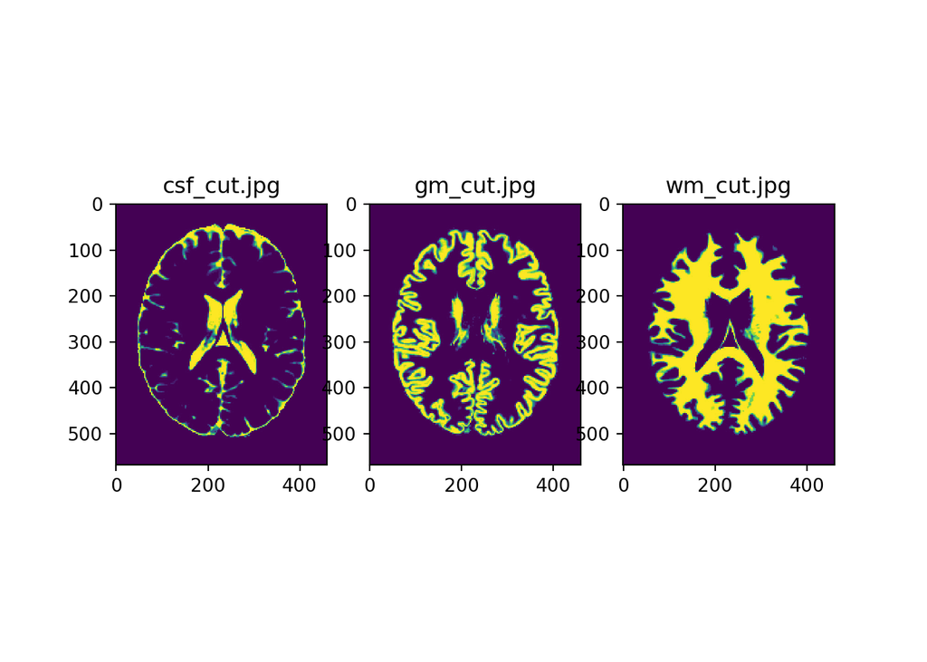

```python
plt.show()
```

2. Ecrivez une fonction qui s’appelera « binarizing_mask » et qui transforme les niveaux de gris compris entre 0 et 127 en la valeur 0 et les valeurs comprises en 128 et 255 en la valeur 255. Cette fonction doit renvoyer l’image transformée.

```python
# def binarizing_mask(img):
#     _, th = cv2.threshold(img, 127, 255, cv2.THRESH_BINARY)
#     return th


def binarizing_mask(img):
  """This function's input is a 2D opencv image which will get binarized."""
  import numpy as np
  for i in range(img.shape[0]):
      for j in range(img.shape[1]):
          img[i, j] = np.where(img[i, j] <= 127, 0, 255)
  return img
```

```python
plt.figure(figsize=(12,7))
plt.subplot(2, 2, 1)
plt.imshow(cv2.imread('data/irm1_cut.jpg')),plt.title('irm1_cut')
```

```
## (<matplotlib.image.AxesImage object at 0x000000002614C3C8>, Text(0.5,1,'irm1_cut'))
```

```python
plt.subplot(2, 2, 2)
plt.imshow(cv2.imread('data/csf_mask.jpg')),plt.title('csf_mask')
```

```
## (<matplotlib.image.AxesImage object at 0x00000000268BA898>, Text(0.5,1,'csf_mask'))
```

```python
plt.subplot(2, 2, 3)
plt.imshow(cv2.imread('data/gm_mask.jpg')),plt.title('gm_mask')
```

```
## (<matplotlib.image.AxesImage object at 0x00000000268EE320>, Text(0.5,1,'gm_mask'))
```

```python
plt.subplot(2, 2, 4)
plt.imshow(cv2.imread('data/wm_mask.jpg')),plt.title('wm_mask')
```

```
## (<matplotlib.image.AxesImage object at 0x0000000026916D68>, Text(0.5,1,'wm_mask'))
```

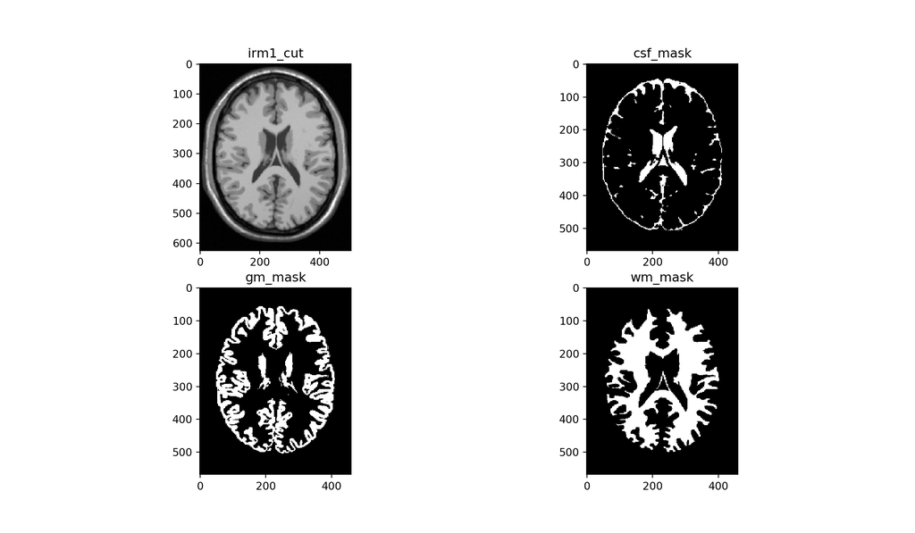

```python
plt.show()
```